# Risor ruber - Genetic analyses: relatedness and basic popgen

2026-08-12

This code refers to Bunholi et al. 2026 “Ecological constraints of habitat specialization shape the social organization and life-history of a sponge-dwelling goby.”

## Analysis overview

### Required inputs

All inputs are provided in `data/relatedness_popgen/`:

- “pop_m5_r07_wl_biallelic_mac5.noHWEexcess_p1e4_LDpruned.vcf” (population structure vcf)
- “rel_m5_r095_wl_biallelic_mac16.noHWEexcess_p1e4.LDpruned.vcf” (relatedness vcf)
- “Risor_ruber_2023_Pairwise_Distances.csv” (pairwise geographic distances)
- “Risor_rel_pan_1664SNPs_withDist.csv” (dyad distances + relatedness data)
- “Risor_metadata_geno_subset_with_all_variables.csv” (metadata all)

User: please run this R Markdown file from the Scripts/ directory.

### Software setup

The following chunk lists the packages required by this report.

```r
# Install required packages before the first run.
# Uncomment these commands only if the packages are not already installed.

# install.packages(c(
#   "tidyverse", "ggrepel", "lme4", "lmerTest", "performance",
#   "vcfR", "hierfstat", "adegenet", "BiocManager", "remotes"
# ))

# SNPRelate is installed through Bioconductor:
# BiocManager::install("SNPRelate")

# radiator is installed from GitHub:
# remotes::install_github("thierrygosselin/radiator")

#load packages
pkgs <- c(
  "tidyverse", "ggrepel", "lme4", "lmerTest", "SNPRelate",
  "performance", "vcfR", "hierfstat", "adegenet", "radiator"
)
invisible(lapply(pkgs, require, character.only = TRUE))
```

[output not shown]

### Data preparation

This section defines project relative paths, imports the two VCF datasets and associated tabular data, and standardizes identifiers used for individual and dyad matching. Generated intermediate files are written to `outputs/`.

```r
# Run this R Markdown file from the Scripts/ directory. All required inputs
# are read from data/relatedness_popgen/ and generated files go to outputs/.
data_dir <- file.path("..", "data", "relatedness_popgen")
output_dir <- file.path("..", "outputs")
dir.create(output_dir, recursive = TRUE, showWarnings = FALSE)

vcf_all <- file.path(data_dir, "pop_m5_r07_wl_biallelic_mac5.noHWEexcess_p1e4_LDpruned.vcf")
vcf_rel <- file.path(data_dir, "rel_m5_r095_wl_biallelic_mac16.noHWEexcess_p1e4.LDpruned.vcf")
dist <- read.csv(file.path(data_dir, "Risor_ruber_2023_Pairwise_Distances.csv"))
rel_df <- read.csv(file.path(data_dir, "Risor_rel_pan_1664SNPs_withDist.csv"))
gds_out <- file.path(output_dir, "pop_m5_r07_wl_biallelic_mac5.noHWEexcess_p1e4_LDpruned.vcf.gds")

meta_all <- read_csv(file.path(data_dir, "Risor_metadata_geno_subset_with_all_variables.csv")) #overall metadata
meta_all <- meta_all %>%
  mutate(sponge_id = if_else(sponge_id == "GOL_06", "GOL_6", sponge_id))
sponge_meta <- meta_all %>%
  dplyr::select(id, sponge_id, S_width_cm, Reef, S_species)
```

```r
#helper functions
std_id <- function(x) x |> stringr::str_trim() |> gsub("-", "_", x = _) #standardizing names
std_pair <- function(a, b) if_else(a < b, paste(a,b,sep="__"), paste(b,a,sep="__")) #standardizing dyad direction
```

### Prepare the COANCESTRY input

The relatedness VCF is converted to the allele-coded format required by COANCESTRY. The expected output is `outputs/new_coancestry_input_filtered_dataset_related.txt`; relatedness estimation itself is performed in COANCESTRY outside R (Windows GUI software https://www.zsl.org/about-zsl/resources/software/coancestry)

```r
related_data<- tidy_vcf(vcf_rel) #filtered dataset
```

```
## ℹ Reading VCF✔ Reading VCF [117ms]
##
## Cleaning VCF
##
## Filter monomorphic markers
## Number of individuals / strata / chrom / locus / SNP:
##     Blacklisted: 0 / 0 / 0 / 0 / 0
## Filter common markers: only 1 strata, returning data
```

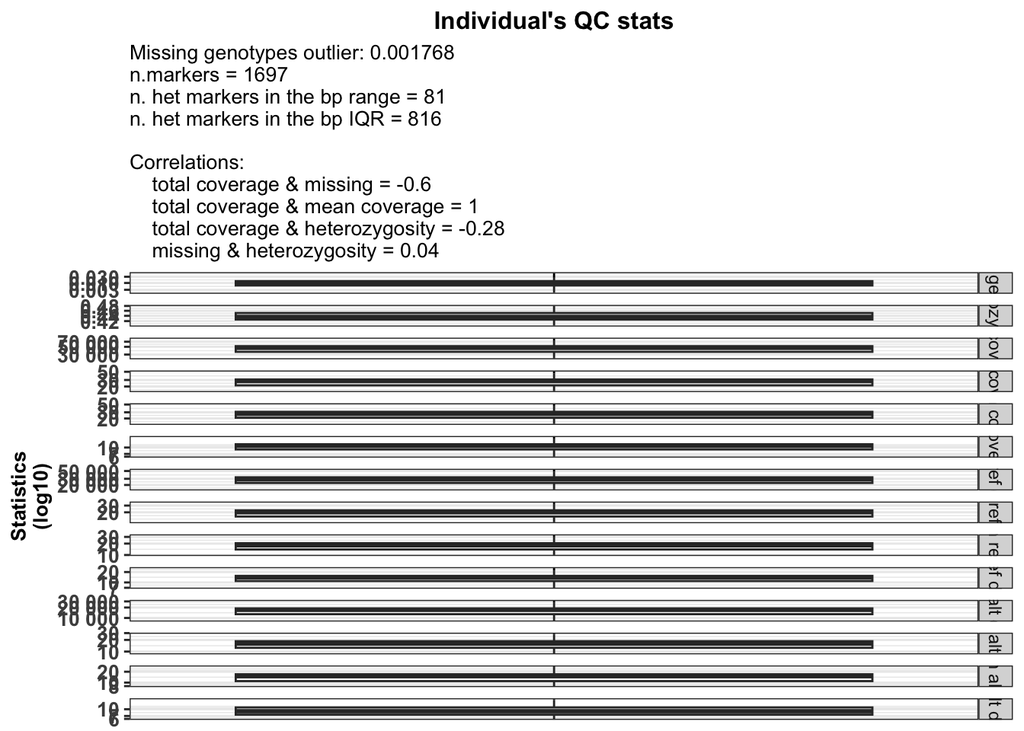

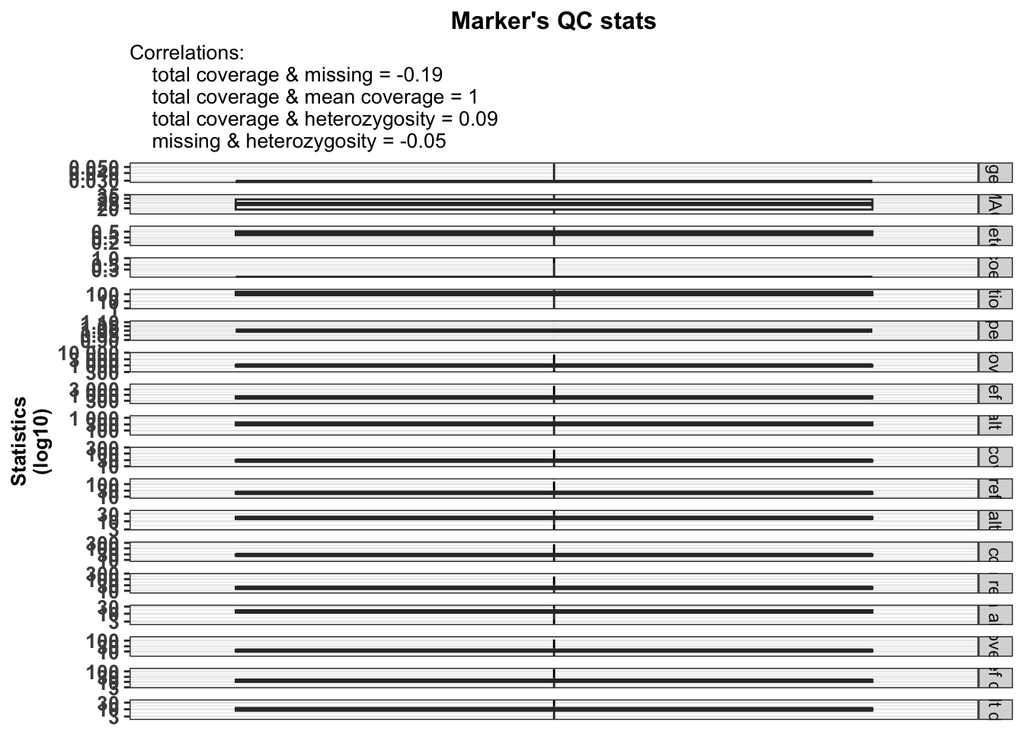

```
##
## VCF info:
## Number of chromosome/contig/scaffold: 1
## Number of locus: 1697
## Number of markers: 1697
## Number of strata: 1
## Number of individuals: 35
##
## Number of ind/strata:
## 1pop = 35
##
## Number of duplicate id: 0
## radiator Genomic Data Structure (GDS) file: radiator_20260812@1408.gds
##
## Genotypes formats generated with 1697 SNPs:
##     GT_BIN (the dosage of ALT allele: 0, 1, 2 NA): TRUE
##     GT_VCF (the genotype coding VCFs: 0/0, 0/1, 1/1, ./.): FALSE
##     GT_VCF_NUC (the genotype coding in VCFs, but with nucleotides: A/C, ./.): FALSE
##     GT (the genotype coding 'a la genepop': 001002, 001001, 000000): FALSE
## AD column: splitting into ALLELE_REF_DEPTH and ALLELE_ALT_DEPTH
## DP column: cleaning and renaming to READ_DEPTH
## HQ values are all missing: removing column
## GL column: cleaning Genotype Likelihood column
## GQ column: Genotype Quality
##
## Computation time, overall: 7 sec
```

```r
#Check what genotype columns exist
names(related_data)
```

```
##  [1] "VARIANT_ID"       "MARKERS"          "CHROM"            "LOCUS"
##  [5] "POS"              "COL"              "REF"              "ALT"
##  [9] "INDIVIDUALS"      "STRATA"           "GT_BIN"           "ALLELE_REF_DEPTH"
## [13] "ALLELE_ALT_DEPTH" "READ_DEPTH"       "GL_HOM_REF"       "GL_HET"
## [17] "GL_HOM_ALT"       "GQ"
```

```r
#VCF generated from STACKS does not have a GT column, but GT_BIN
#GT_BIN: 0 = homozygous reference (0/0); 1 = heterozygous (0/1); 2 = homozygous alternative (1/1); NA = missing data

#Create GT column based on GT_BIN
related_data$GT <- dplyr::case_when(
  related_data$GT_BIN == 0 ~ "001001",  #homozygous reference
  related_data$GT_BIN == 1 ~ "001002",  #heterozygous
  related_data$GT_BIN == 2 ~ "002002",  #homozygous alternate
  TRUE ~ "000000"                       #missing data
)

#writing Coancestry input
radiator::write_related(
  data = related_data,
  filename = file.path(output_dir, "new_coancestry_input_filtered_dataset.txt"))
```

#### Compare relatedness estimators

The deposited COANCESTRY results contain several estimators. Their Spearman correlations are compared here to document estimator agreement and support use of the Wang estimator in the downstream models. rel_df is the output from COANCESTRY. The code above is only to instruct how to generate COANCESTRY input file from a VCF since it can be really tricky; however, it is not needed to reproduce the results since the relatedness estimations are already being provided.

```r
rel_all <- rel_df %>%
  transmute(
    Individual1 = std_id(Individual1),
    Individual2 = std_id(Individual2),
    pair = std_pair(std_id(Individual1), std_id(Individual2)),
    Distance_m,
    Wang, Ritland, LynchRd, LynchLi, QuelletGt, TrioML
  )
```

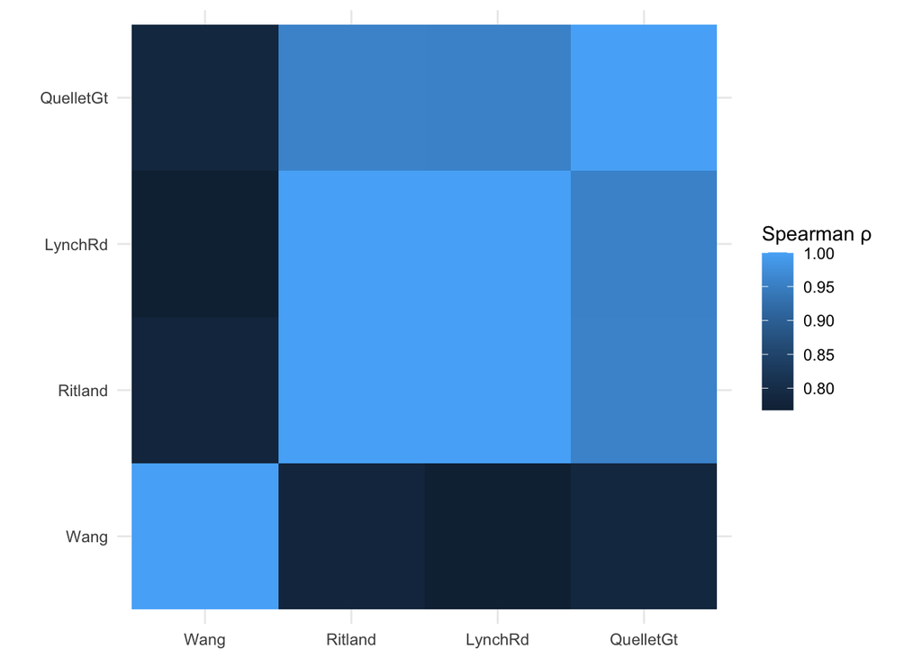

```r
estimators <- c("Wang","Ritland","LynchRd","QuelletGt")

cor_mat <- cor(rel_all[,estimators], method="spearman", use="pairwise.complete.obs") #generating correlation matrix

as.data.frame(as.table(cor_mat)) %>%
  ggplot(aes(Var1, Var2, fill=Freq)) +
  geom_tile() +
  theme_minimal() +
  labs(x=NULL, y=NULL, fill="Spearman ρ") +
  coord_equal()
```

All p values are high (~0.8–1.0), showing strong correlation between metrics. Wang was then chosen because it performs well with moderate SNP numbers (Wang, 2002).